# Seinna R Verkefni

Óskar Höskuldsson (osh16@hi.is) og Viktor Sigbjörn Víðisson (vsv8@hi.is)

1. Búið til verkefni (e. Project) í vinnumöppunni ykkar og nefnið það seinna_r_verkefni.
2. Lesið gagnaskrána husnaedisverd_2017.csv inn í R/RStudio og geymið í hlut sem ber upphafsstafi þeirra sem verkefnið vinna (ef Gréta Halldórsdóttir og Sigurður Jónsson eru að vinna saman skulu þau nefna hlutinn gs en ef Atli Pétursson er að vinna einn skal hann nefna hlutinn sinn ap). Kannið gerð breytanna og breytið gerð þeirra sem eru ekki af réttri gerð (ef einhverjar).

```r
ov <- read.table("husnaedisverd_2017.csv", header=TRUE, sep=";")
```

3. Breytan kaupverd er í þúsundum króna, breytið henni þannig að hún verði í krónum.

```r
ov$kaupverd = ov$kaupverd*1000
```

4. Búið til nýja breytu í gagnarammanum ykkar sem inniheldur fermetraverð eignanna, nefnið breytuna fermetraverd.

```r
ov$fermetraverd = ov$kaupverd/ov$birtm2
```

5. Búið til nýja breytu sem þið skulið kalla teg_eign_groft sem byggir á teg_eign breytunni. Breytan á að innihalda tvo flokka: Sérbýli (Einbýlishús, Parhús, Raðhús) og Íbúð (Íbúðareign). Ábending: notið fct_recode() aðferðina.

```r
ov$teg_eign_groft <- forcats::fct_recode(ov$teg_eign, Sérbýli="Einbýlishús", Sérbýli="Parhús", Sérbýli="Raðhús", Íbúð="Íbúðareign")
```

6. Búið til nýja gagnagrind (dataframe) sem inniheldur eignir úr þremur hverfum í Reykjavík og kallið hana rvk. Þið veljið hvaða hverfi sjálf en hverfin sem þið veljið þurfa að innihalda a.m.k. 200 eignir, þarf af 30 sérbýli.

```r
hverfi <- c(80,330,800)
rvk <- dplyr::filter(ov, matssvaedi%in%hverfi)
```

7. Breytið matssvaedi breytunni í rvk gagnarammanum í flokkabreytu og nefnið flokkana með heiti hverfanna.

```r
rvk$matssvaedi[rvk$matssvaedi == 80] = "Hlíðar"
rvk$matssvaedi[rvk$matssvaedi == 330] = "Kópavogur:Hjallar,Smárar"
rvk$matssvaedi[rvk$matssvaedi == 800] = "Mosfellsbær"
rvk$matssvaedi = factor(rvk$matssvaedi, levels=c("Hlíðar","Kópavogur:Hjallar,Smárar","Mosfellsbær"))
```

8. Hugsum okkur nú að eignirnar í rvk gagnarammanum ykkar sé þýðið ykkar. Nú ætlum við að taka úrtak úr þýðinu, 100 eignir úr hverju hverfi.

```r
set.seed(19)
rvk %>%
  group_by(matssvaedi) %>%
  sample_n(size = 100) -> urtak1
```

1. Búið til töflu sem sýnir hlutfall sérbýla og íbúða í hverfunum þremur. Það á s.s. að vera hægt að lesa hver hlutföll sérbýla og íbúða er í hverju hverfi fyrir sig.

```r
tafla <- prop.table(table(rvk$matssvaedi, rvk$teg_eign_groft))
```

10. Kannið með kí-kvaðrat prófi hvort marktækur munur sé á hlutfalli sérbýla í hverfunum þremur. Sýnið úttakið úr prófinu. Setjið tilgátunar fram formlega. Sýnið úttakið úr prófinu. Tilgreinið gildið á prófstærðinni, p-gildið og hvaða ályktun þið dragið í samfelldu máli.

```r
ki_kvadrat <- chisq.test(tafla)
ki_kvadrat
```

```
##
##  Pearson's Chi-squared test
##
## data:  tafla
## X-squared = 0.28942, df = 2, p-value = 0.8653
```

Núlltilgáta: $H_{0}=\mu_{1}=\mu_{2}$

Gagntilgáta: $H_{1}=\mu_{1}\neq\mu_{2}$

11. Hvaða forsendur þurfa að vera uppfylltar svo framkvæma megi kí-kvaðrat próf? Eru forsendurnar uppfylltar í prófinu í j-lið?

```r
ki_kvadrat$expected
```

```
##
##                               Sérbýli      Íbúð
##   Hlíðar                   0.08626128 0.3633986
##   Kópavogur:Hjallar,Smárar 0.07999722 0.3370096
##   Mosfellsbær              0.02557823 0.1077551
```

Í fyrsta lagi verður hver athugun að vera óháð hinum á þá vegu að ekki er hægt að finna út gildi eins þátttakanda út frá frammistöðu annars. Til dæmis: Það hvort einn þátttakandi veiti aðstoð þegar fönguleg kona missir blaðabunka á ekki að tengjast því hvort hún fái hjálp frá öðrum við síðara tækifæri. Vegna þessa er óheimilt að prófa sama þátttakandann oftar en einu sinni.

Í öðru lagi þarf úrtakið að vera nokkuð stórt svo væntigildin verði ekki mjög lág. Algengt viðmið (sem þó er ekki alheilagt) er að ekkert væntigildi sé lægra en fimm, að því gefnu að summa raða og dálka séu ekki mjög skekktar. Þó er varasamt að reikna Pearson kíkvaðrat í töflu með mjög lágum væntigildum vegna þess hve það dregur úr afköstum prófsins. Dreifing nálgast að öllu jöfnu normaldreifingu eftir því sem fjöldi athuganna eykst og að því gefnu að breytan sé normaldreifð í þýði.

12. Teiknið mynd sem sýnir fermetraverð eftir tegund eigna (sérbýli-íbúðir). Hér á að nota gögnin úr hverfunum ykkar þremur en ekki að skipta upp eftir hverfunum.

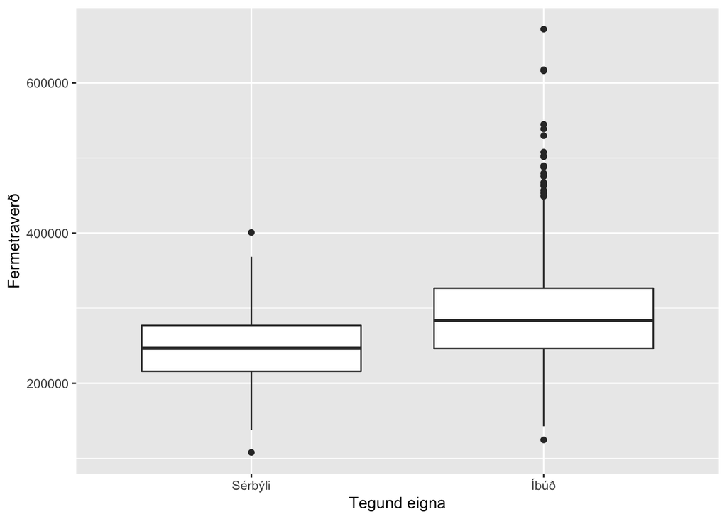

```r
ggplot(data=rvk, aes(x=teg_eign_groft, y=fermetraverd)) + geom_boxplot() + xlab("Tegund eigna") + ylab("Fermetraverð")
```

13. Kannið með viðeigandi tilgátuprófi hvort munur sé á meðalfermetrverði sérbýla og íbúða. Hér eigið þið að nota gögnin úr hverfunum ykkar þremur en ekki skipta þeim upp eftir hverfunum. Setjið tilgáturnar fram formlega. Sýnið úttakið úr prófinu. Tilgreinið gildið á prófstærðinni, p-gildið og hvaða ályktun þið dragið í samfelldu máli.

```r
tilgata <- t.test(rvk$fermetraverd~rvk$teg_eign_groft, alternative = "two.sided")
tilgata
```

```
##
##  Welch Two Sample t-test
##
## data:  rvk$fermetraverd by rvk$teg_eign_groft
## t = -12.993, df = 543.45, p-value < 0.00000000000000022
## alternative hypothesis: true difference in means is not equal to 0
## 95 percent confidence interval:
##  -49032.12 -36153.03
## sample estimates:
## mean in group Sérbýli    mean in group Íbúð
##              247472.4              290065.0
```

Núlltilgáta: $H_{0}=\mu_{1}=\mu_{2}$

Gagntilgáta: $H_{1}=\mu_{1}\neq\mu_{2}$

Prófstærð = -12.993, fríðgráðurnar eru 543.45 og p-gildi = 0.00000000000000022 svo að núlltilgátu er hafnað. Þar með drögum við þá ályktun að það sé munur á meðalfermetraverði sérbýla og íbúða í þessum þrem hverfum.

14. Smíðið 95% öryggisbil fyrir mismun á meðaltölum sérbýla og einbýla. Setjið öryggisbilið fram á formlegan hátt.

```r
orbil <- tilgata$conf.int
```

Öryggisbilið er -49032.12 < $\mu$ < -36153.03

15. Teiknið mynd sem sýnir fermetraverð íbúða eftir hverfunum þremur.

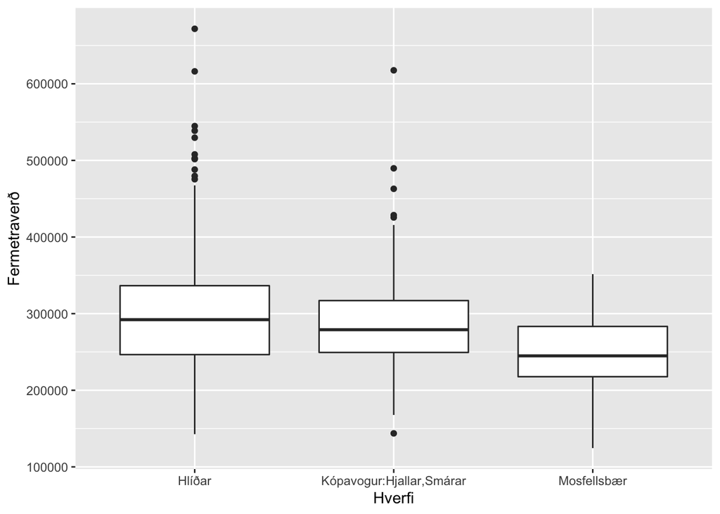

```r
ggplot(data=filter(rvk, teg_eign_groft=="Íbúð"),aes(x=matssvaedi, y=fermetraverd)) + geom_boxplot() + xlab("Hverfi") + ylab("Fermetraverð")
```

16. Kannið með viðeigandi tilgátuprófi hvort munur sé á meðalfermetrverði íbúða eftir hverunum þremur. Setjið tilgáturnar fram formlega. Sýnið úttakið. Tilgreinið gildið á prófstærðinni, p-gildið og hvaða ályktun þið dragið í samfelldu máli.

```r
tilgata <- anova(aov(fermetraverd~matssvaedi, filter(rvk, teg_eign_groft=="Íbúð")))
profstaerd <- tilgata$`F value`[1]
p_gildi <- tilgata$`Pr(>F)`[1]

tilgata
```

```
## Analysis of Variance Table
##
## Response: fermetraverd
##              Df        Sum Sq     Mean Sq F value         Pr(>F)
## matssvaedi    2  142894538324 71447269162  19.533 0.000000004504 ***
## Residuals  1185 4334377320880  3657702380
## ---
## Signif. codes:  0 '***' 0.001 '**' 0.01 '*' 0.05 '.' 0.1 ' ' 1
```

Núlltilgáta: $H_{0}=\mu_{1}=\mu_{2}$

Gagntilgáta: $H_{1}=\mu_{1}\neq\mu_{2}$

Prófstærð = 19.53337, fríðgráðurnar eru tvær og p-gildi = 0.000000004504022. p-gildið er minna en prófstærðin svo núlltilgátunni er hafnað. Þar með drögum við þá ályktun að það sé munur á meðalfermetraverði íbúða í þessum þrem hverfum.

17. Teiknið mynd sem sýnir sambandið á milli stærðar og verðs íbúðaeignanna í hverfunum ykkar þremur.

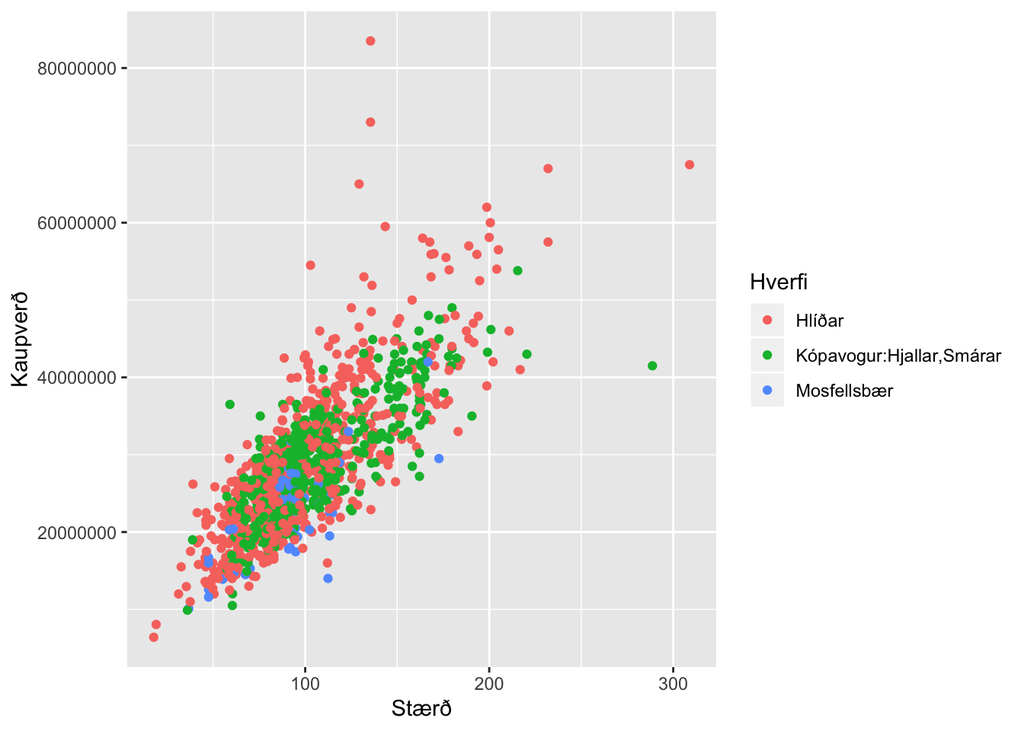

```r
ggplot(data=filter(rvk, teg_eign_groft == "Íbúð"), aes(x=birtm2, y=kaupverd, color=matssvaedi)) + geom_point() + labs(x = "Stærð", y = "Kaupverð", color="Hverfi")
```

18. Smíðið aðhvarfsgreiningarlíkan sem nota má til að spá fyrir um verð eigna út frá stærð. Hér eigið þið að nota gögnin úr hverfunum ykkar þremur en ekki skipta þeim upp eftir hverfunum. Sýnið úttakið. Tilgreinið í textanum hvert matið ykkar á skurðpunktinum og hallatölunni eru. Segið með örfáum orðum hvort þið teljið skynsamlegt að nota líkan sem þetta til að spá fyrir um verð út frá stærð eignanna.

```r
ves <- lm(formula = birtm2 ~ kaupverd, data=urtak1)
likan <- summary(ves)
hallatala <- likan$`coefficients`[1]
skurdpunktur <- likan$`coefficients`[2]

likan
```

```
##
## Call:
## lm(formula = birtm2 ~ kaupverd, data = urtak1)
##
## Residuals:
##      Min       1Q   Median       3Q      Max
## -153.221  -18.565   -2.838   13.912  136.639
##
## Coefficients:
##                  Estimate    Std. Error t value            Pr(>|t|)
## (Intercept) -5.4999472789  4.7573513536  -1.156               0.249
## kaupverd     0.0000040304  0.0000001314  30.672 <0.0000000000000002 ***
## ---
## Signif. codes:  0 '***' 0.001 '**' 0.01 '*' 0.05 '.' 0.1 ' ' 1
##
## Residual standard error: 30.34 on 298 degrees of freedom
## Multiple R-squared:  0.7594, Adjusted R-squared:  0.7586
## F-statistic: 940.7 on 1 and 298 DF,  p-value: < 0.00000000000000022
```

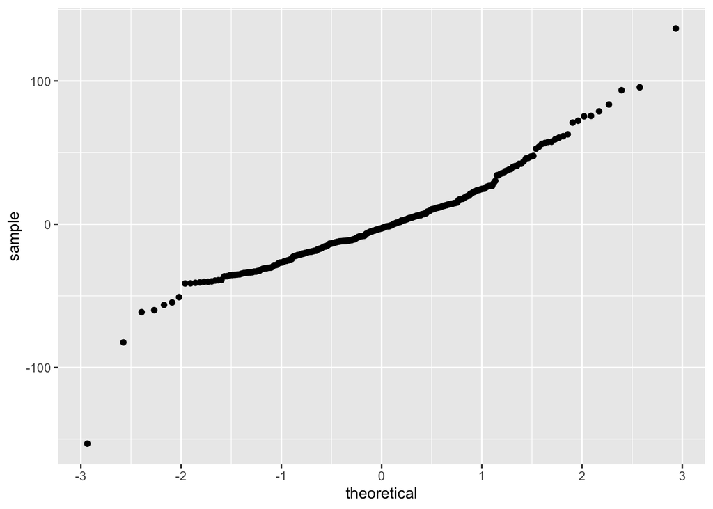

```r
ggplot(ves, aes(sample=.resid)) + stat_qq()
```